# A 3D model of the Paris area using the Google elevation API and OpenSCAD

Thu, 30 Oct 2014

[Geography](http://flothesof.github.io/tag/geography.html) [3D Printing](http://flothesof.github.io/tag/3d-printing.html)

**Update November 3, 2014**: I printed the model using an Ultimaker. You can find it on [Thingiverse](http://www.thingiverse.com/thing:530054). Here's what it looks like when printed.

[figure not shown]

In this post, we will use the elevation API provided by Google maps to obtain some height information about a section of Paris, and then build an 3D model to be printed from the data. The end result we are trying to achieve should look much the same as the image shown below (the source of the image is [this Thingiverse thing](http://www.thingiverse.com/thing:136312)).

```python
from IPython.display import Image
Image(url="http://thingiverse-production.s3.amazonaws.com/renders/d7/de/ac/dc/f4/sakurajima_preview_featured.jpg")
```

[figure not shown]

Let's get started.

# Getting the source height data

## Sample data

Our first step is to get the height data we need for our 3D representation. We're going to use Google data that we can access using the elevation API. The elevation API usage is described [here](https://developers.google.com/maps/documentation/elevation/). Users of the free API can do the following:

- 2,500 requests per 24 hour period.
- 512 locations per request.
- 25,000 total locations per 24 hour period.
- 5 requests per second.

Below, we're executing the (sligthly modified) sample script found on the [API documentation page](https://developers.google.com/maps/documentation/elevation/) to get some elevation data along a line defined by start and end coordinates.

```python
import simplejson
import urllib

ELEVATION_BASE_URL = 'https://maps.googleapis.com/maps/api/elevation/json'
CHART_BASE_URL = 'http://chart.apis.google.com/chart'

def getElevation(path="36.578581,-118.291994|36.23998,-116.83171",samples="100", **elvtn_args):
    elvtn_args.update({
    'path': path,
    'samples': samples})

    url = ELEVATION_BASE_URL + '?' + urllib.urlencode(elvtn_args)
    response = simplejson.load(urllib.urlopen(url))

    # Create a dictionary for each results[] object
    elevationArray = []

    for resultset in response['results']:
        elevationArray.append(resultset['elevation'])

    return elevationArray
```

```python
# Mt. Whitney
startStr = "36.578581,-118.291994"
# Death Valley
endStr = "36.23998,-116.83171"

pathStr = startStr + "|" + endStr

elevationArray = getElevation(pathStr)
```

To visualize the data we have just downloaded, we can plot it:

```python
from pylab import *
%matplotlib inline
```

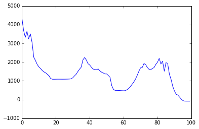

```python
plot(elevationArray)
```

This "line data" will be used in the next section to obtain all the data we need for a 3D model. Before we move on, I'd like to explore the detailed results obtained by the API request.

```python
elvtn_args = {}
elvtn_args.update({
    'path': pathStr,
    'samples': "200"})
url = ELEVATION_BASE_URL + '?' + urllib.urlencode(elvtn_args)
response = simplejson.load(urllib.urlopen(url))
```

As one can see below, `response` is a dictionary containing the status and the results related to the request we just made.

```python
response.keys()
```

```
['status', 'results']
```

The status reports whether the request worked or not. Here, it is:

```python
response['status']
```

```
'OK'
```

The results are a list of dictionaries containing the coordinate points.

```python
response['results'][:5]
```

```
[{'elevation': 4350.96044921875,
  'location': {'lat': 36.578581, 'lng': -118.291994},
  'resolution': 305.4064636230469},
 {'elevation': 3765.516845703125,
  'location': {'lat': 36.57692408822881, 'lng': -118.2846242328207},
  'resolution': 305.4064636230469},
 {'elevation': 3697.862548828125,
  'location': {'lat': 36.57526672284261, 'lng': -118.27725478197},
  'resolution': 305.4064636230469},
 {'elevation': 3629.592529296875,
  'location': {'lat': 36.57360890388832, 'lng': -118.2698856475017},
  'resolution': 305.4064636230469},
 {'elevation': 3324.3681640625,
  'location': {'lat': 36.57195063141282, 'lng': -118.2625168294698},
  'resolution': 305.4064636230469}]
```

These coordinates can be extracted to produce a sample 3D plot.

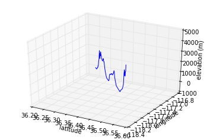

```python
from mpl_toolkits.mplot3d import Axes3D
fig = plt.figure()
ax = fig.add_subplot(111, projection='3d')
xs = [item['location']['lat'] for item in response['results']]
ys = [item['location']['lng'] for item in response['results']]
zs = [item['elevation'] for item in response['results']]
ax.plot3D(xs, ys, zs)
xlabel('latitude')
ylabel('longitude')
ax.set_zlabel('elevation (m)')
```

## Defining a grid of elevations and retrieving heights

Now that we know how to retrieve elevation data from a given path defined by start and end points, we can extend this method to work with a grid. In the next cells, we will discretize a portion of the globe roughly corresponding to the location of Paris (although any portion of map could do) and gather its elevation data.

First, we define the portion of the map we want to use by its coordinates (in fact, its "top left" and "bottom right"). We also plot it using `Basemap` to make sure that our bounding coordinates are correctly selected.

```python
top_left = (48.960092, 2.158060) #latitude, longitude
bottom_right = (48.802953, 2.456751)
```

```python
from mpl_toolkits.basemap import Basemap
```

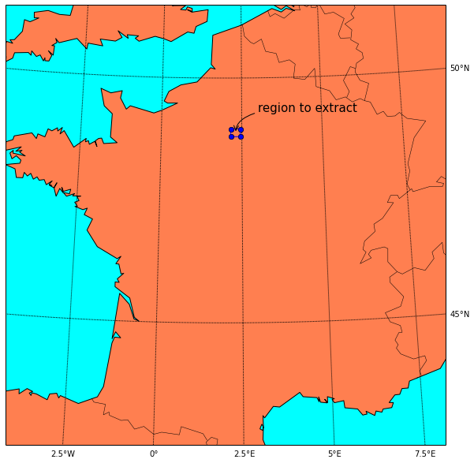

```python
# setup Lambert Conformal basemap.
figure(figsize=(10, 10))
m = Basemap(width=1000000, height=1000000, projection='lcc',
            resolution='l',
            lat_0=47.,lon_0=2.)
# draw coastlines
m.drawcoastlines()
# draw a boundary around the map, fill the background.
# this background will end up being the ocean color, since
# the continents will be drawn on top.
m.drawmapboundary(fill_color='aqua')
# fill continents, set lake color same as ocean color.
m.fillcontinents(color='coral',lake_color='aqua')
m.drawcountries()
# meridians on bottom and left
parallels = np.arange(45, 55, 5.)
# labels = [left,right,top,bottom]
m.drawparallels(parallels, labels=[False,True,True,False])
meridians = np.arange(-2.5, 10, 2.5)
m.drawmeridians(meridians,labels=[True,False,False,True])


# computing remaining points of bounding rectangle
top_right = (top_left[0], bottom_right[1])
bottom_left = (bottom_right[0], top_left[1])

for start, end in zip([top_left, top_right, bottom_right, bottom_left],
                      [top_right, bottom_right, bottom_left, top_left]):
    x0, y0 = m(start[1], start[0])
    x1, y1 = m(end[1], end[0])
    m.plot([x0, x1], [y0, y1], '-bo')

region_center = (0.5 * (top_left[0] + bottom_right[0]),
                 0.5 * (top_left[1] + bottom_right[1]))
xy_region_center = m(region_center[1], region_center[0])

annotate("region to extract", [xy_region_center[0], xy_region_center[1]],
         [xy_region_center[0] + 50000, xy_region_center[1] + 50000],
         arrowprops=dict(arrowstyle="->",
                connectionstyle="angle3,angleA=0,angleB=-90"),
         fontsize=15)
```

This looks like what we expect: a rectangle of data located in the northern part of France.

The next step is to discretize a grid based on the coordinates that we have been using so far so that we can retrieve elevation data for each grid point to create a height map. We create a grid of latitudes and longitudes based on the bounding box coordinates.

```python
min_longitude, max_longitude = top_left[1], bottom_right[1]
latitudes = linspace(top_left[0], bottom_right[0], 200)
longitudes = linspace(min_longitude, max_longitude, 200)
```

And now we loop over all trajectories extracting 200 points on each line using the Google elevation API.

```python
import time
```

```python
start_t = time.time()
data = []
for ind, lat in enumerate(latitudes):
    path = "{0},{1}|{2},{3}".format(lat, min_longitude, lat, max_longitude)
    elvtn_args = {'path': path,
                  'samples': '200'}
    url = ELEVATION_BASE_URL + '?' + urllib.urlencode(elvtn_args)
    response = simplejson.load(urllib.urlopen(url))
    while not response['status'] == 'OK':
        print "response was not ok for request(index: {0}, path: {1}), will retry shortly.".format(ind, path)
        time.sleep(0.5)
        response = simplejson.load(urllib.urlopen(url))
    data.append(response)
```

That's it. We have now downloaded the data we need for our 3D modelling task.

## Plotting the height data

Below, we loop over the results in our dataset and append them to a list. We then reshape the data into a matrix for easier handling. Finally, we build a coordinate mesh and plot the elevation data and some contour surfaces.

```python
def build_elevationArray():
    elevationArray = []
    for result_set in data:
        for result_point in result_set['results']:
            elevationArray.append(result_point['elevation'])
    return array(elevationArray).reshape((200, 200))
```

```python
elevationArray = build_elevationArray()
```

```python
Y, X = meshgrid(latitudes, longitudes) # needed for nicely displaying the contours
```

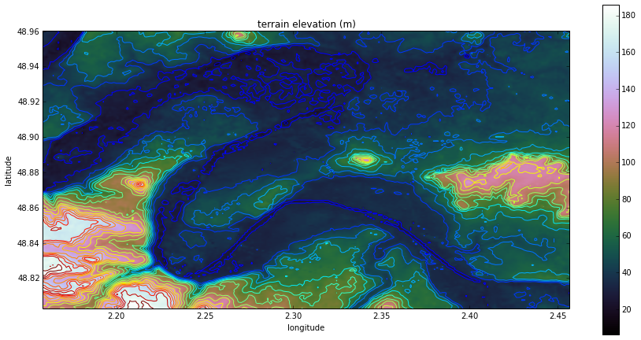

```python
figure(figsize=(15, 15))
imshow(elevationArray, cmap='cubehelix', extent=(min_longitude, max_longitude, latitudes.min(), latitudes.max()))
colorbar(shrink=0.5)
title('terrain elevation (m)')
xlabel('longitude')
ylabel('latitude')

CS = contour(X, Y, elevationArray.T, 20)
```

This looks quite beautiful. We can also just plot the contours of this map.

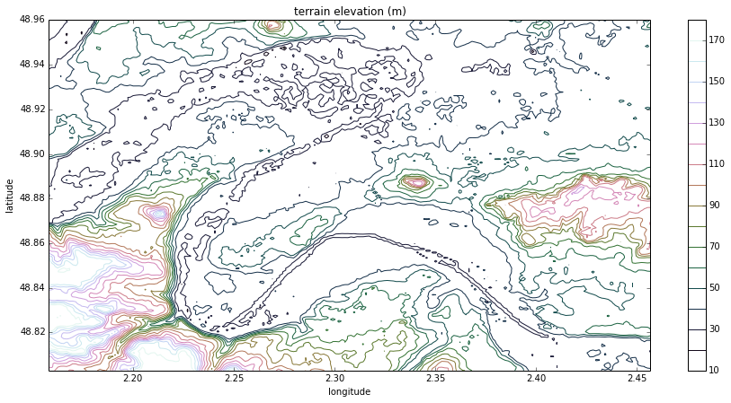

```python
figure(figsize=(15, 7))
contour(X, Y, elevationArray.T, 20, cmap='cubehelix')
colorbar()
title('terrain elevation (m)')
xlabel('longitude')
ylabel('latitude')
```

# Building a 3D model from the height data

In the following cells, we will build a 3D model from the height data. To achieve this, we will extract the geometrical data from the contour sets we just used in the previous plot and extrude them in the $z$ direction. The extrusion will be done by generating code for the [OpenSCAD modeller](http://www.openscad.org/). This will allow us to directly convert the model to the meshed STL format used by a 3D printer.

The reason I am generating code for OpenSCAD is that it's really easy to use. For instance, extruding a triangle of height and width equal to 100 mm in the $z$ direction over 10 mm can be expressed by the following line:

> linear_extrude(height = 10) polygon(points=[[0,0],[100,0],[0,100]]);

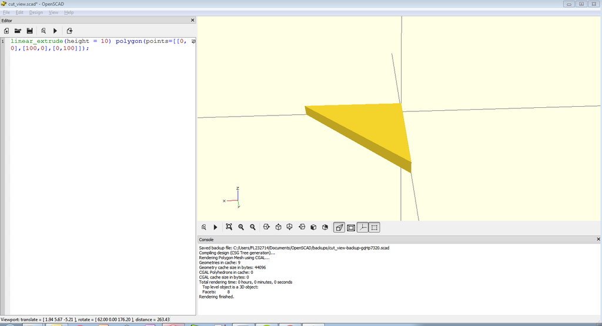

```python
Image(filename='files/OpenSCAD.PNG')
```

First, we generate the contour we want to work with.

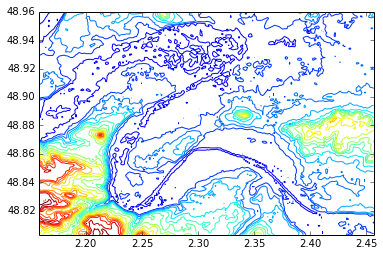

```python
CS = contour(X, Y, elevationArray.T, 20)
```

Next, we extract a collection of paths for each isosurface (whose existence I have discovered by reading [this link](http://stackoverflow.com/questions/17494047/how-to-smooth-a-plot-in-matplotlib-without-losing-contour-lines) - before I thought that I should use "segments"...). Each path is made of vertices, which we can plot. The lines obtained by this will be extruded in our 3D model.

```python
def get_vertices(CS, isosurface_index):
    lc = CS.collections[isosurface_index]
    vertices = []
    for path in lc.get_paths():
        vertices.append(path.vertices)
    return vertices
```

These vertices can be plotted:

```python
def plot_isosurface(isosurface_index):
    figure(1, figsize=(10, 4))

    subplot(121)
    title("height {0} meters".format(CS.levels[isosurface_index]))
    vertices = get_vertices(CS, isosurface_index)
    for v in vertices:
        plot(v[:, 0], v[:, 1])
    xlim(longitudes.min(), longitudes.max())
    ylim(latitudes.min(), latitudes.max())

    subplot(122)
    contour(X, Y, elevationArray.T, CS.levels, cmap='cubehelix')
```

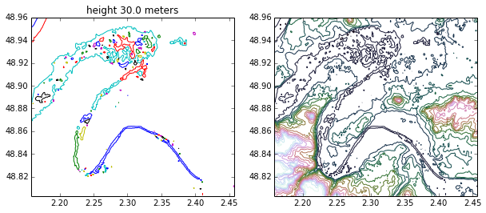

```python
plot_isosurface(2)
```

This can even be made interactive.

```python
from IPython.html.widgets import interact
```

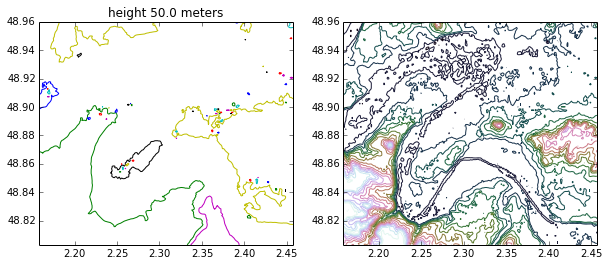

```python
interact(plot_isosurface,
         isosurface_index=(0, len(CS.collections) - 1))
```

Now that we have all the vertices we need in our mesh, we can build up a 3D extension of those. We need to convert the coordinates from each point of the segment from latitude longitude coordinates to some coordinates appropriate to the OpenSCAD modelling.

We compute the extent of our model below.

```python
lon_mini = longitudes.min()
lat_mini = latitudes.min()
dx = longitudes.max() - longitudes.min()
dy = latitudes.max() - latitudes.min()
```

```python
dx, dy
```

```
(0.29869100000000026, 0.15713900000000081)
```

Next, we define a scaling factor that will permit to compute the final dimensions of our object. Our scaling factor will be the target $dx$ (longitude extent) of our object, expressed in millimeters.

```python
scaling_factor = 100. #mm
```

This allows us to write some scaling functions.

```python
scale_lon = lambda lon: scaling_factor / dx * (lon - lon_mini)
scale_lat = lambda lat: scaling_factor / dx * (lat - lat_mini)
```

From this, we can define a function that scales the coordinates of a point and returns some OpenSCAD compatible string:

```python
array2str = lambda arr: "[{0:.5f}, {1:.5f}]".format(scale_lon(arr[0]), scale_lat(arr[1]))
```

Using the previous function, we can define a function that loops over all points and returns an extruded version using the `polygon` command of OpenSCAD. The function below takes into account a starting elevation due to the fact that we will stack extrusions on top of each other to build the final 3D model.

```python
def vertices2extrusion(vertices, start_height, extrusion_height):
    polygon = "[" + ", ".join([array2str(point) for point in vertices]) + "]"
    return "translate([0, 0, {0}]) linear_extrude(height={1}) polygon({2});".format(start_height, extrusion_height, polygon)
```

```python
vertices2extrusion(get_vertices(CS, 2)[0], 0, 10)
```

```
'translate([0, 0, 0]) linear_extrude(height=10) polygon([[0.00000, 49.52006], [0.35937, 49.70117], [0.50251, 49.83891], [0.79369, 49.96554], [1.00503, 50.05929], [1.19791, 50.22991], [1.44856, 50.49427], [1.50754, 50.54141], [1.73315, 50.75864], [1.89860, 51.02301], [2.01005, 51.17476], [2.10872, 51…
```

```python
vertices2extrusion(get_vertices(CS, 2)[0], 20, 10)
```

```
'translate([0, 0, 20]) linear_extrude(height=10) polygon([[0.00000, 49.52006], [0.35937, 49.70117], [0.50251, 49.83891], [0.79369, 49.96554], [1.00503, 50.05929], [1.19791, 50.22991], [1.44856, 50.49427], [1.50754, 50.54141], [1.73315, 50.75864], [1.89860, 51.02301], [2.01005, 51.17476], [2.10872, 5…
```

Now that we have our basic functions, we can apply this to all segments in our contours and output this to a 3D file. We will use define a z scaling factor much in the same way that we scaled our latitude and longitude above.

```python
scaling_factor_z = 50. / 200. # target size in z is 50 mm
scale_z = lambda z: scaling_factor_z * z
```

```python
def generate_model_code(CS, filename='files/model.scad'):
    """ generates OpenSCAD model code and writes it to file.
    """
    model = ""
    for index in range(len(CS.collections)): # loop over every isosurface
        current_height = CS.levels[index]
        if index != (len(CS.collections) - 1):
            current_extrusion = CS.levels[index + 1] - CS.levels[index]
        else:
            current_extrusion = CS.levels[index] - CS.levels[index - 1]
        vertices_list = get_vertices(CS, index)

        # loop for one layer
        layer = ""
        for v in vertices_list:
            layer += vertices2extrusion(v,
                                        scale_z(current_height),
                                        scale_z(current_extrusion))
        model += layer

    # write to file
    with open(filename, 'w') as f:
        f.write(model)
```

```python
generate_model_code(CS)
```

At this point, we have a working model. However, I noticed that we don't have a flat plate upon which the whole structure rests. So at this point I'm going back one step and manually setting the borders of our data to zero so that the isocontours we get are naturally bounded.

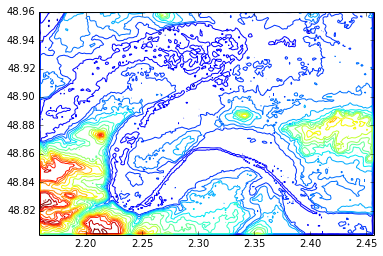

```python
elevationArray[:, 0] = elevationArray[:, -1] = 0
elevationArray[0, :] = elevationArray[-1, :] = 0
CS = contour(X, Y, elevationArray.T, 20)
```

As one can see, there now are borders on the edges of the model. This naturally builds a support plate for our 3D model.

```python
generate_model_code(CS, filename='files/model_bounded.scad')
```

Another experiment we can do is to spatially filter the data with a Gaussian filter. This will smooth all contours.

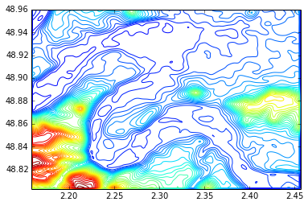

```python
from scipy.ndimage import gaussian_filter

elevationArray = build_elevationArray() # rebuild data
elevationArray = gaussian_filter(elevationArray, 2) # filter it

elevationArray[:, 0] = elevationArray[:, -1] = 0 # make sure there's a nice border
elevationArray[0, :] = elevationArray[-1, :] = 0

CS = contour(X, Y, elevationArray.T, 50) # build contour set

generate_model_code(CS, filename='files/model_bounded_smoothed.scad') # write model
```

Finally, we can display a little gallery of the generated models we now have.

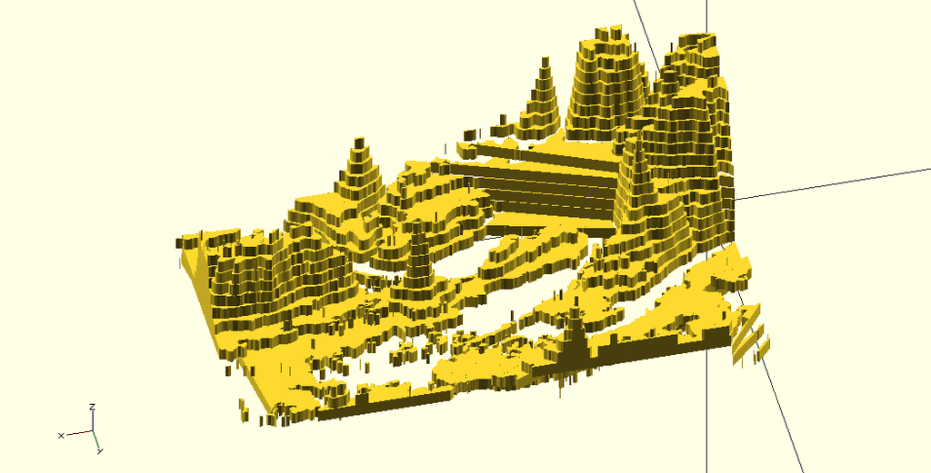

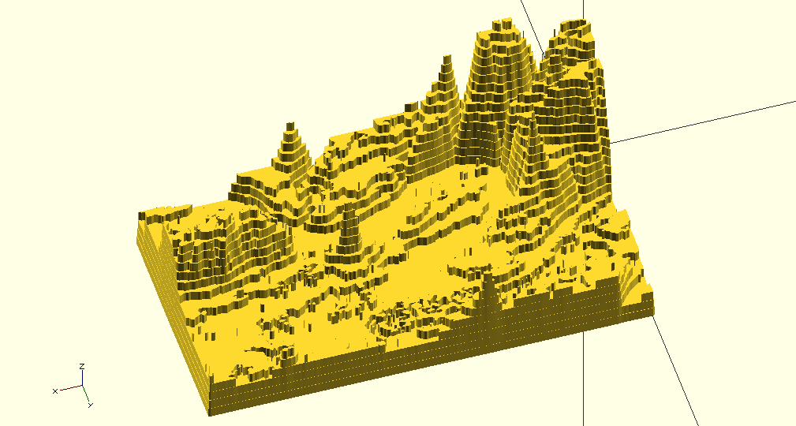

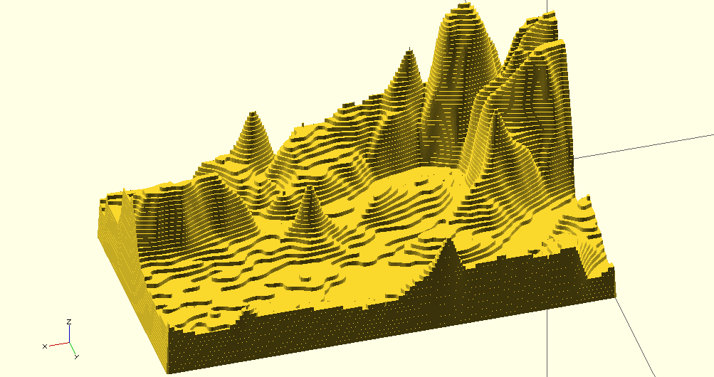

```python
from IPython.display import display
for f in ['files/OpenSCAD_model.PNG', 'files/OpenSCAD_model_bounded.PNG', 'files/OpenSCAD_model_bounded_smoothed.PNG']:
    display(Image(filename=f))
```

Final and last step: print it using a 3D printer!

# Conclusions

In this post, we have learned how to use the Google elevation API to retrieve height data for a grid of geographical coordinates centered about Paris. This data was used in conjunction with the powerful numeric Python tools to produce a smooth mesh that was rendered using the OpenSCAD language. This 3D model can be exported to the STL format, ready for 3D printing.

The tools developed within this post are generic and could thus make it possible to produce a similarly rendered 3D model of any region of the world.

This post was entirely written using the IPython notebook. You can see a static view or download this notebook with the help of nbviewer at 20141027_ParisTopology.ipynb.

This article has been tagged with the following terms:

[Geography](http://flothesof.github.io/tag/geography.html) [3D Printing](http://flothesof.github.io/tag/3d-printing.html)

[figure not shown]